# Utilisation de Strava chez les coureurs amateurs

# Mesure de l’auto-présentation

La présentation de soi est la tentative d’un individu de contrôler la façon dont les autres le perçoivent <sup>3</sup>. Dans l’article de Russell (2023), il y a des témoignanges sur le contrôle : « Si c’est une course très lente, je ne la mettrais peut-être pas sur Strava.», « Je n’aime pas poster des courses qui ne font pas au moins 3 miles, parce que c’est un peu comme une course de mauviette, comme si vous ne terminiez pas au moins un 5K, pour moi, ce n’est pas une bonne journée. Vous devriez au moins être capable de faire un 5 km. Parce que je ne veux pas que mes followers se demandent pourquoi elle est si lente », « Parfois, je cours un ou deux kilomètres de plus, juste parce que ça a l’air mieux sur Strava. ». <sup>3</sup>

Mais il y a également des témoignages qui se rapproche plus d’une présentation authentique : « Et donc je suppose que je me sens comme… plus capable d’être honnête et moi-même sur Strava et c’est moins une question de photos et d’image et plus une question de ma propre course », « Même si la course n’a pas été géniale, je dirai à l’avance que j’ai eu des difficultés mentales aujourd’hui… J’ai l’impression d’être très ouvert sur Strava en ce qui concerne les bons et les mauvais jours.» <sup>3</sup>

Le Self-presentation and Upward Social Comparison Inclination Scale mesure l’auto-présentation sur les réseaux sociaux. <sup>10</sup> <sup>17</sup> L’échelle comporte initialement 7 items qui ont été traduits et adaptés à l’étude. Le SPAUSCIS mesure le degré de focalisation sur l’auto-présentation et la comparaison sociale ascendante sur les réseaux sociaux. Il évalue plusieurs aspects du comportement des adolescents sur les réseaux sociaux, notamment la recherche de feedback, l’auto-présentation “améliorée” et la comparaison sociale avec des personnes perçues commet “meilleures”. Il est à noter que cette échelle a été utilisée auprès d’adolescent. Dans l’étude de Hjetland (2022) <sup>17</sup>, l’alpha est de 0.87.

Suite au pré-test, un item a été enlevé dans l’étude sur Strava (“It is important to me that my posts receive many likes and/or comments”). L’échelle traduite et adaptée comporte donc **6 items**.

Un score bas au SPAUSCIS indique que l’utilisateur accord peu d’importance à leur image sur Strava (ne recherche pas activement du feedback, pas de stratégie d’auto-présentation, pas de comparaison aux utilisateurs perçus comme “meilleurs”, pas de contrôle d’image) tandis qu’un score haut indique que l’utilisateur accorde beaucoup d’importance à son image sur Srava (recherche active de feedback, stratégie d’auto-présentation, comparaison aux autres, contrôle de l’image).

Les scores obtenus sur l’échantillon sont bas, ce qui signifie que les individus n’ont pas de stratégie d’auto-présentation pour paraître “meilleurs”.

### SPAUSCIS

```
## L'alpha de Cronbach sur les 6 items est de 0.544747605721729
```

L’alpha de Cronbach est assez faible, cela peut s’expliquer par le fait que c’est une traduction et adaptation dans le cadre de cette étude du questionnaire d’origine mais également par le fait que ce questionnaire était destiné plutôt à des publics adolescents.

#### SPAUSCIS 1

| Moyenne | Médiane | Ecart_type |
| --- | --- | --- |
| 1.463087 | 1 | 0.685129 |

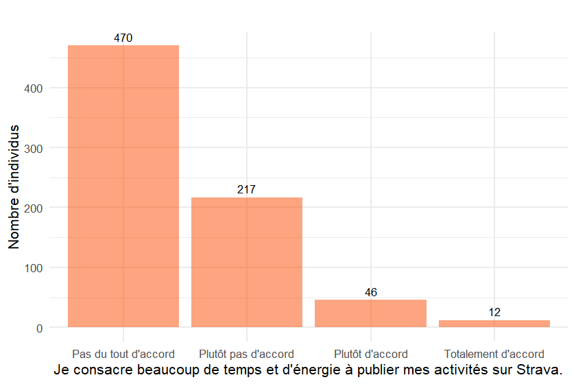

#### SPAUSCIS 2

| Moyenne | Médiane | Ecart_type |
| --- | --- | --- |
| 1.30604 | 1 | 0.5465223 |

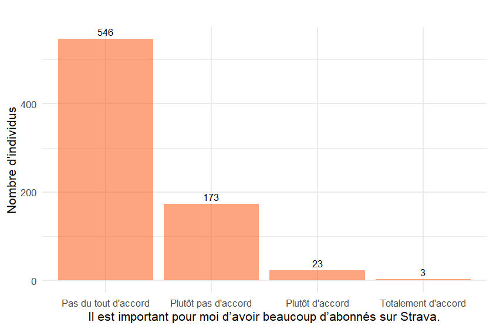

#### SPAUSCIS 3

| Moyenne | Médiane | Ecart_type |
| --- | --- | --- |
| 1.013423 | 1 | 0.1365166 |

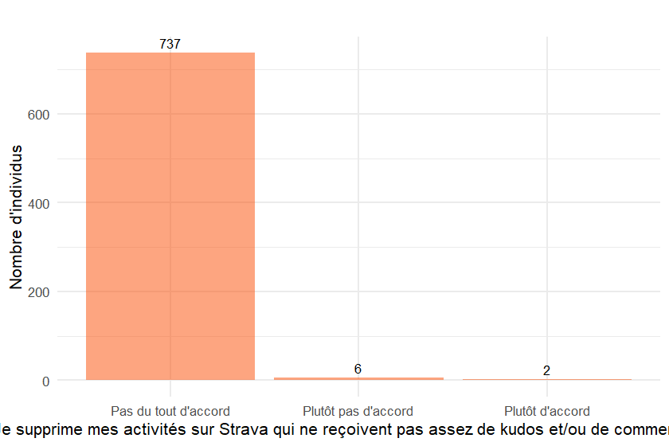

#### SPAUSCIS 4

| Moyenne | Médiane | Ecart_type |
| --- | --- | --- |
| 1.10604 | 1 | 0.3925085 |

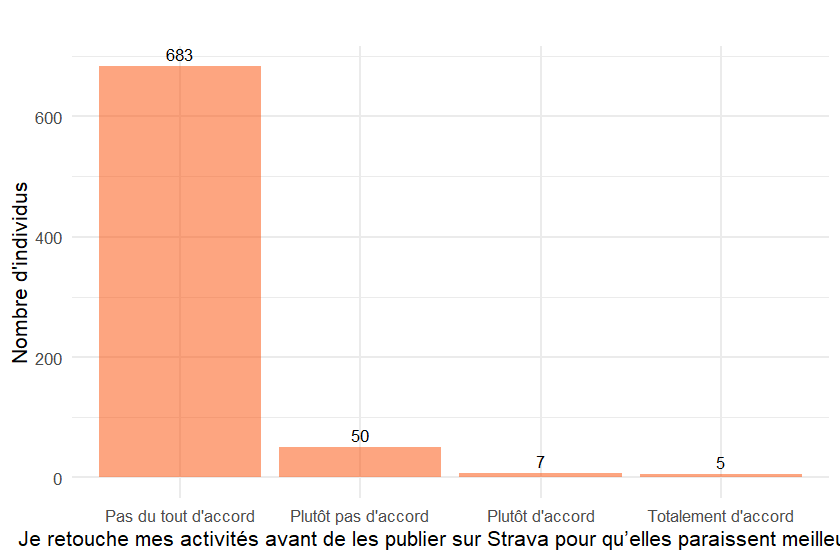

#### SPAUSCIS 5

| Moyenne | Médiane | Ecart_type |
| --- | --- | --- |
| 1.381208 | 1 | 0.6953541 |

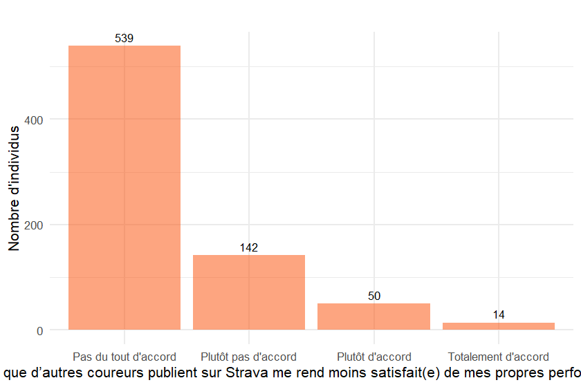

#### SPAUSCIS 6

| Moyenne | Médiane | Ecart_type |
| --- | --- | --- |
| 1.526174 | 1 | 0.7635335 |

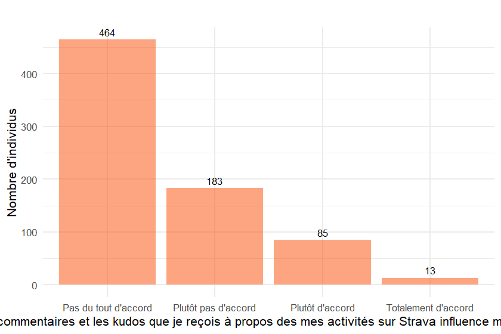

#### SCORE SPAUSCIS

| Item | Moyenne | Médiane | Ecart_type |
| --- | --- | --- | --- |
| SPAUSCIS1 | 1.463087 | 1.000000 | 0.6851290 |
| SPAUSCIS2 | 1.306040 | 1.000000 | 0.5465223 |
| SPAUSCIS3 | 1.013423 | 1.000000 | 0.1365166 |
| SPAUSCIS4 | 1.106040 | 1.000000 | 0.3925085 |
| SPAUSCIS5 | 1.381208 | 1.000000 | 0.6953541 |
| SPAUSCIS6 | 1.526174 | 1.000000 | 0.7635335 |
| SCORE_SPAUSCIS | 1.299329 | 1.166667 | 0.3195509 |

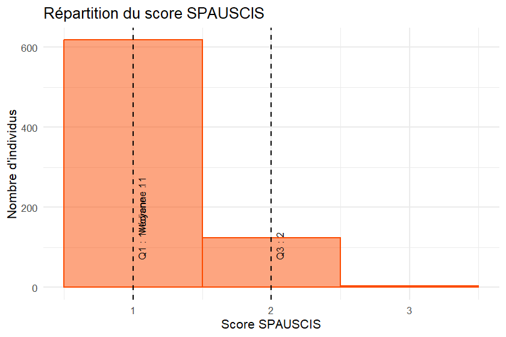

# Lien utilisation de Strava - présentation de soi (hypothèse 2)

Il s’agit de savoir s’il y a un lien entre l’utilisation de Strava et le score SPAUSCIS.

**Rappel de l’hypothèse 2 : plus les coureurs amateurs utilisent Strava, plus ils sont susceptibles de filtrer ou modifier ce qu’ils partagent pour contrôler leur image.**

On peut tester les liens entre les variables Strava suivantes avec le score SPAUSCIS :

- Score SIS
- Score OSF
- Score exposition
- Appartenance à des clubs Strava
- Nombre de kudos reçus en moyenne par activité
- Nombre de publications par semaine (fréquence de publication)
- Nombre de consultations par semaine (fréquence de consultation)
- Nombre d’abonnés
- Nombre d’abonnements
- Ancienneté sur Strava
- Catégorie d’abonnement (gratuit/payant)

### Statistiques

#### Corrélations

| Variable | Corr_SCORE_SPAUSCIS | P_value | Significatif |
| --- | --- | --- | --- |
| Score SIS | 0.43 | 0.0000 | <0.05 |
| Score OSF | 0.3 | 0.0000 | <0.05 |
| Score d’Exposition | 0.23 | 0.0000 | <0.05 |
| Appartenance à un club Strava | 0.15 | 0.0000 | <0.05 |
| Nombre de kudos reçus par activité | 0.19 | 0.0000 | <0.05 |
| Fréquence de publication | 0.07 | 0.0631 | ≥0.05 |
| Fréquence de consultation | 0.21 | 0.0000 | <0.05 |
| Nombre d’abonnés | 0.16 | 0.0000 | <0.05 |
| Nombre d’abonnements | 0.15 | 0.0001 | <0.05 |
| Ancienneté sur Strava (années) | 0.01 | 0.7191 | ≥0.05 |

#### Visualisation graphique

##### SIS

[figure not shown]

##### OSF

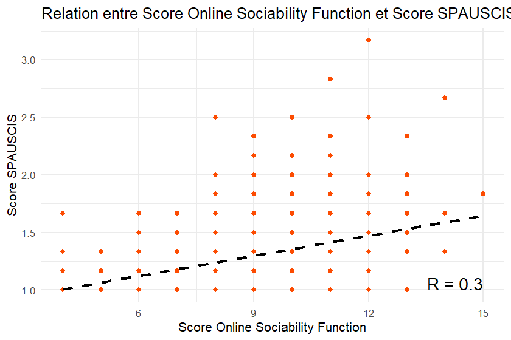

#### Test t de Student

| Variable | Student | p_value | Significatif | Gratuit | Payant |
| --- | --- | --- | --- | --- | --- |
| Catégorie d’abonnement et SPAUSCIS | -2.352556 | 0.0189048 | <0.05 | 1.279046 | 1.336502 |

#### Visualisation graphique

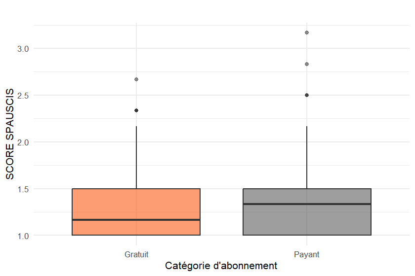

### Conclusion hypothèse 2

**Rappel de l’hypothèse 2 : plus les coureurs amateurs utilisent Strava, plus ils sont susceptibles de filtrer ou modifier ce qu’ils partagent pour contrôler leur image.**

Les scores au SPAUSCIS restent relativement bas (Q3 = 2). Attention, l’alpha de Cronbach est assez faible pour le score SPAUCIS donc les conclusions ne sont pas très fiables.

Le score SIS (0.43) et le score OSF (0.3) sont modérément corrélés au score SPAUSCIS.

Le score EXPO (0.23), le nombre de clubs Strava (0.15), les kudos reçus en moyenne par activité (0.19), la fréquence de consultation (0.21), le nombre d’abonnés (0.16) et le nombre d’abonnements (0.15) sont faiblement corrélés au score SPAUSCIS.

La moyenne du score SPAUSCIS est significativement plus élévée chez les utilisateurs ayant un compte payant (test t de Student, p<0.05, significatif).

# Lien présentation de soi - caractéristiques sportives (hypothèse 2)

Pour aller plus loin dans l’hypothèse 2, il s’agit de savoir s’il y a un lien entre le score SPAUSCIS et les caractéristiques sportives.

On peut tester le score SPAUCIS avec les variables sportives suivantes :

- nombre de kilomètres par semaine (volume par semaine)
- nombre d’entraînements par semaine (fréquence entraînement)
- nombre de compétitions par an
- niveau
- type de coureur (trail/route, club/pas club, seul/en groupe)
- suivi d’un programme d’entraînement
- accompagnement par un coach
- type d’objectif 2025 s’il y en a un
- blessure ou non liée à la course à pied dans les 6 derniers mois
- durée de la pause d’une blessure liée à la course à pied

### Statistiques

#### Corrélations

| Variable | Corr_SCORE_SPAUSCIS | P_value | Significatif |
| --- | --- | --- | --- |
| Nombre de kilomètres par semaine | -0.09 | 0.0109 | <0.05 |
| Nombre d’entraînements par semaine | -0.09 | 0.0173 | <0.05 |
| Compétitions | 0.11 | 0.0028 | <0.05 |

#### Test t de Student

| Variable | Student | P_value | Significatif | Avec_coach | Sans_coach |
| --- | --- | --- | --- | --- | --- |
| Coach et SPAUSCIS | -0.1140976 | 0.9091913 | ≥ 0.05 | 1.296667 | 1.3 |

| Variable | Student | P.value | Signficatif | Avec_programme | Sans_programme |
| --- | --- | --- | --- | --- | --- |
| Programme et SPAUSCIS | 1.717416 | 0.0863198 | ≥ 0.05 | 1.329662 | 1.286036 |

| Variable | Student | P.value | Significatif | Blessure | Pas_de_blessure |
| --- | --- | --- | --- | --- | --- |
| Blessure et SPAUSCIS | 0.0010804 | 0.9991382 | ≥ 0.05 | 1.299346 | 1.29932 |

#### ANOVA

| Variable | F_value | P_value | Significatif | Débutant | Intermédiaire | Confirmé | Expert |
| --- | --- | --- | --- | --- | --- | --- | --- |
| Lien score SPAUSCIS et niveau | 0.4572719 | 0.7122354 | ≥ 0.05 | 1.277778 | 1.287665 | 1.313568 | 1.315315 |

| Variable | F_value | P_value | Significatif |
| --- | --- | --- | --- |
| Lien score SPAUSCIS et type coureur | 0.5687244 | 0.7816408 | ≥ 0.05 |

| Type_coureur | Moyenne |
| --- | --- |
| Route/Club/Seul | 1.287879 |
| Route/Pas club/Seul | 1.359375 |
| Route/Club/En groupe | 1.303119 |
| Route/Pas club/En groupe | 1.250000 |
| Trail/Club/Seul | 1.329427 |
| Trail/Pas club/Seul | 1.279461 |
| Trail/Club/En groupe | 1.280506 |
| Trail/Pas club/En groupe | NA |

| Variable | F_value | P_value | Significatif | Vingt_km | Cinquante_km | Cent_km | Cent_miles |
| --- | --- | --- | --- | --- | --- | --- | --- |
| Lien score SPAUSCIS et objectif 2025 | 2.38064 | 0.0502723 | ≥ 0.05 | 1.286738 | 1.30791 | 1.337719 | 1.243108 |

| Variable | F_value | P_value | Significatif | Jours | Semaines | Mois | Pas_de_pause |
| --- | --- | --- | --- | --- | --- | --- | --- |
| Lien score SPAUSCIS et pause blessure | 0.5921406 | 0.6684227 | ≥ 0.05 | 1.311508 | 1.322344 | 1.276836 | 1.214286 |

### Conclusion hypothèse 2

**Rappel de l’hypothèse 2 : plus les coureurs amateurs utilisent Strava, plus ils sont susceptibles de filtrer ou modifier ce qu’ils partagent pour contrôler leur image.**

Pour compléter la première conclusion sur l’hypothèse 2, il est possible de se demander si le score SPAUSCIS a un lien avec la pratique (est-ce que par exemple le fait d’avoir une stratégie d’auto-présentation élevée est en lien avec le nombre de kilomètres parcourus par semaine ?)

Il y a une faible corrélation entre le score SPAUSCIS et le nombre de compétitions par an (0.11). Il n’y a pas de corrélation entre le score SPAUSCIS et le nombre de kilomètres et d’entraînements par semaine.

Les conclusions sont peu fiables étant donné l’alpha de Cronbach du SPAUSCIS qui est assez faible.

Il n’est pas possible de mettre en évidence des différences significatives pour le score SPAUSCIS et les personnes suivies par un coach ou non. De même avec les personnes suivant un programme d’entraînement ou non. Et de même avec les personnes ayant eu une blessure liée à la pratique de la course à pied dans les 6 derniers mois ou non. (test de Student, p > 0.05)

Il n’est pas possible de mettre en évidence des différences significatives entre le score SPAUSCIS et les différents niveaux de pratique, de même pour les types de coureurs, les types d’objectifs 2025 (distance) et les différentes durées de pause liées à des blesssures à cause de la course à pied pour les coureurs qui ont été blessés (ANOVA, p > 0.05).

# Mesure du stress perçu

Dans l’article de Rusell<sup>3</sup>, il y a des témoignages concernant la pression perçue “I think it makes you feel like there’s pressure to do as much as other people are doing or as well as other people are doing… I had a really bad run or workout oneday, and I see others having better runs, then that can make me feel worse.

Le Perceived Stress Scale mesure le stress perçu et la capacité d’adaptation. Les items ont étés traduits et adaptés à partir de l’étude de Sischka (2024) <sup>11</sup>. L’étude de Chiu (2016) <sup>13</sup> recommande d’utiliser cette échelle mais en version 2 facteurs : stress perçu et capacité d’adaptation.

L’article de Chiu (2016) <sup>13</sup> indique un alpha de Cronbach de 0.81 pour le stress perçu et 0.71 pour la capacité d’adaptation.

Suite au pré-test, un item a été enlevé dans l’étude sur Strava (“In the last week, how often have you felt that you were on top of things?”). L’échelle traduite et adaptée comporte donc **9 items**.

Un score élevé sur le PSS (facteur stress perçu) indique un stress perçu élévé tandis qu’un score faible indique un stress perçu faible. Un score élevé sur le PSS (facteur capacité d’adaptation) montre que la personne arrive à gérer son stress correctement tandis qu’un score faible indique qu’elle a plus de mal. Ainsi, un individu peut avoir un haut niveau de stress mais aussi une forte capacité d’adaptation et inversement.

Dans l’échantillon, le stress perçu par l’utilisation de Strava est plutôt faible et l’adaptation au stress perçu par l’utilisation de Strava est plutôt élevée.

L’alpha de Cronbach pour le score de l’adaptation au stress est faible du fait de la traduction, adaptation et suppression d’un item suite au pré-test. Les conclusions sont donc peu fiables.

### PSS Facteurs stress perçu

```
## L'alpha de Cronbach sur les 6 items est de 0.670192093450068
```

#### PSS 1

| Moyenne | Médiane | Ecart_type |
| --- | --- | --- |
| 1.060403 | 1 | 0.2701102 |

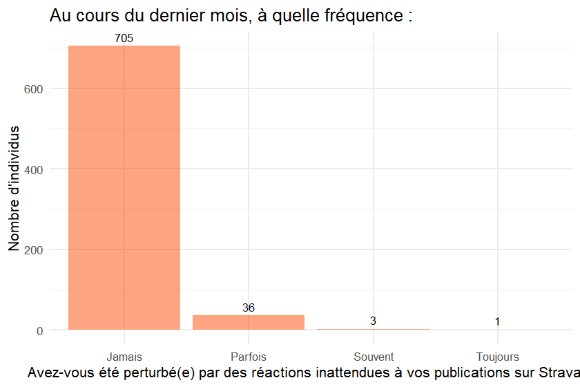

#### PSS 2

| Moyenne | Médiane | Ecart_type |
| --- | --- | --- |
| 1.174497 | 1 | 0.5149844 |

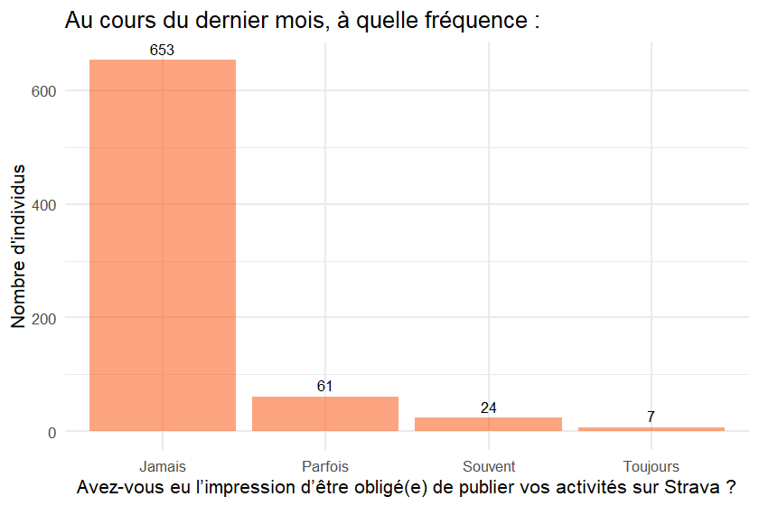

#### PSS 3

| Moyenne | Médiane | Ecart_type |
| --- | --- | --- |
| 1.071141 | 1 | 0.3137304 |

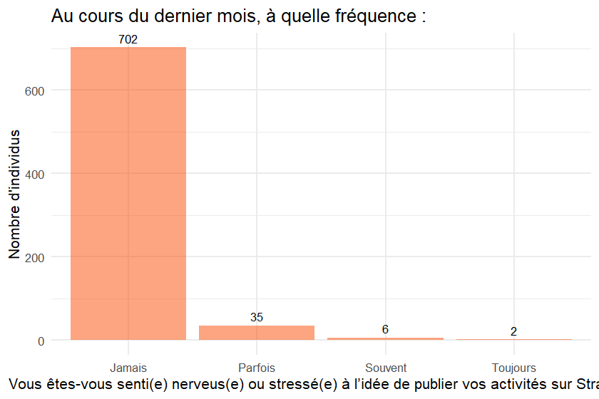

#### PSS 6

| Moyenne | Médiane | Ecart_type |
| --- | --- | --- |
| 1.421477 | 1 | 0.7510355 |

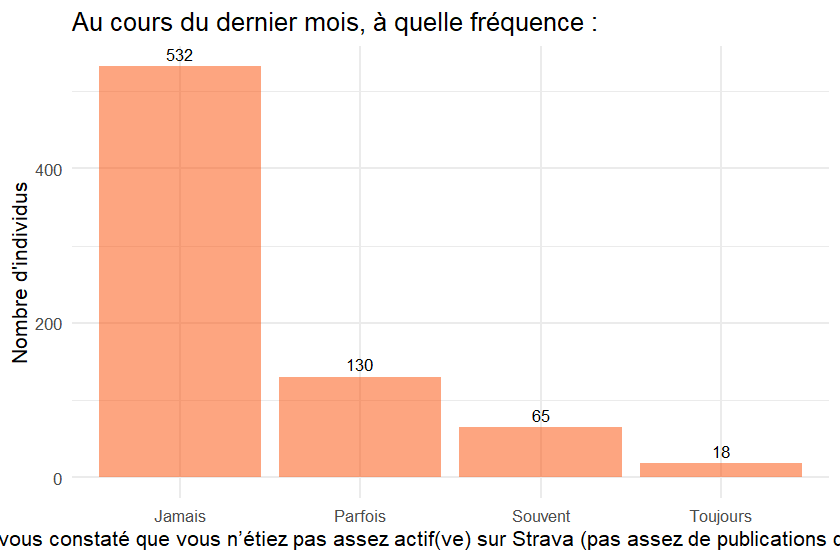

#### PSS 8

| Moyenne | Médiane | Ecart_type |
| --- | --- | --- |
| 1.163758 | 1 | 0.4808447 |

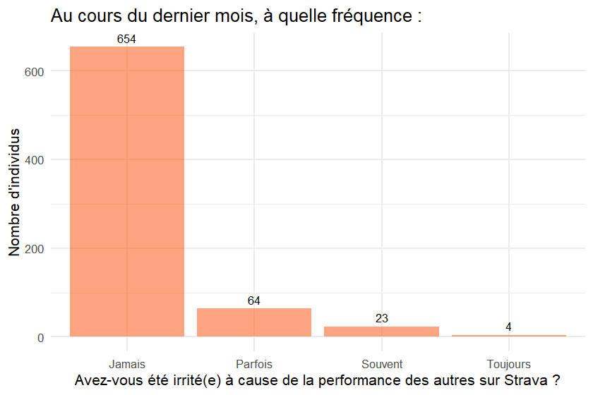

#### PSS 9

| Moyenne | Médiane | Ecart_type |
| --- | --- | --- |
| 1.210738 | 1 | 0.5260858 |

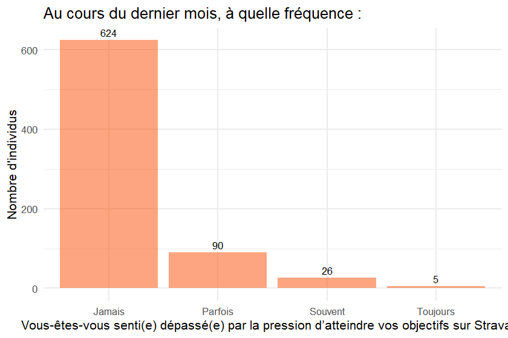

#### SCORE PSS Stress perçu

| Item | Moyenne | Médiane | Ecart_type |
| --- | --- | --- | --- |
| PSS1 | 1.060403 | 1 | 0.2701102 |
| PSS2 | 1.174497 | 1 | 0.5149844 |
| PSS3 | 1.071141 | 1 | 0.3137304 |
| PSS6 | 1.421477 | 1 | 0.7510355 |
| PSS8 | 1.163758 | 1 | 0.4808447 |
| PSS9 | 1.210738 | 1 | 0.5260858 |
| SCORE_PSS_Stress | 7.102013 | 6 | 1.8485125 |

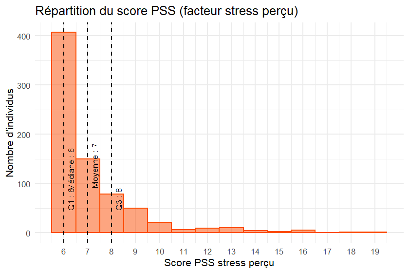

### PSS Facteurs adaptation au stress

```
## L'alpha de Cronbach sur les 3 items est de 0.632857044365542
```

#### PSS 4

| Moyenne | Médiane | Ecart_type |
| --- | --- | --- |
| 2.346309 | 2 | 1.189477 |

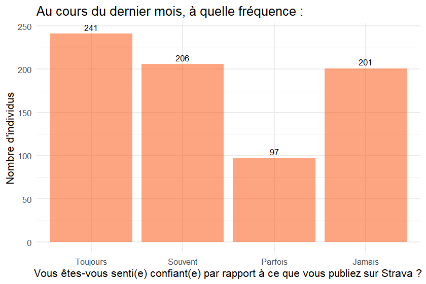

#### PSS 5

| Moyenne | Médiane | Ecart_type |
| --- | --- | --- |
| 2.944966 | 3 | 0.9134182 |

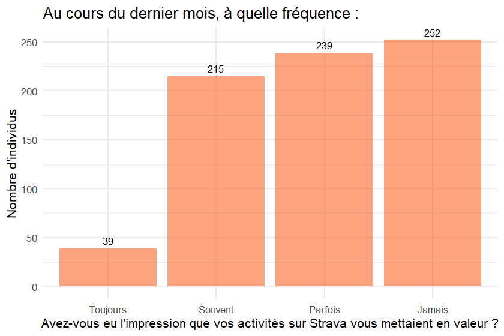

#### PSS 7

| Moyenne | Médiane | Ecart_type |
| --- | --- | --- |
| 2.983893 | 3 | 1.175355 |

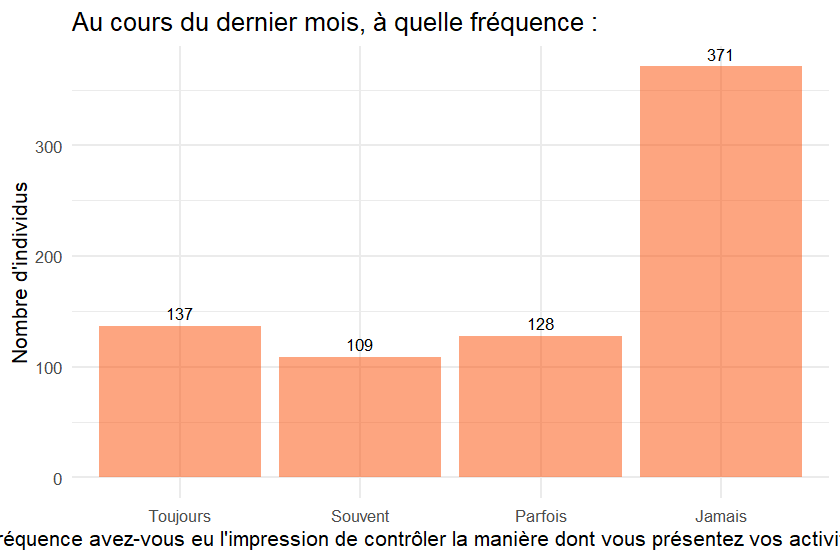

#### SCORE PSS Adapation au stress

| Item | Moyenne | Médiane | Ecart_type |
| --- | --- | --- | --- |
| PSS4 | 2.346309 | 2 | 1.1894769 |
| PSS5 | 2.944966 | 3 | 0.9134182 |
| PSS7 | 2.983893 | 3 | 1.1753555 |
| SCORE_PSS_Adaptation | 8.275168 | 8 | 2.5060654 |

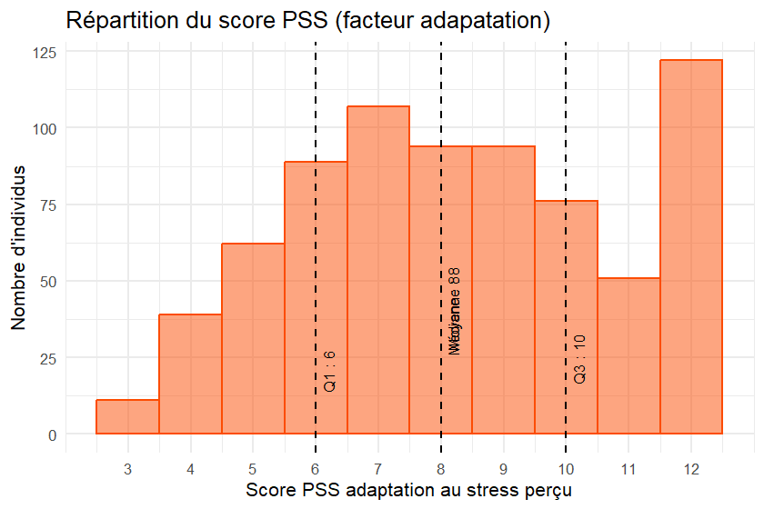

# Lien utilisation de Strava - stress perçu (hypothèse 3)

La question ici est de savoir si l’utilisation de Strava (intensité et fréquence d’utilisation, utilisation des fonctionnalités de sociabilisation en ligne et exposition d’informations personnelles…) engendre un stress perçu ou non.

**Rappel de l’hypothèse 3 : plus les coureurs amateurs utilisent Strava, plus ils sont susceptibles de ressentir du stress.**

On peut tester les liens entre les variables Strava suivantes avec le score PSS “stress perçu” et le score “adaptation au stress”:

- Score SIS
- Score OSF
- Score exposition
- Appartenance à des clubs Strava
- Nombre de kudos reçus en moyenne par activité
- Nombre de publications par semaine (fréquence de publication)
- Nombre de consultations par semaine (fréquence de consultation)
- Nombre d’abonnés
- Nombre d’abonnements
- Ancienneté sur Strava
- Catégorie d’abonnement (gratuit/payant)

### Une première approche

| Moyenne | Médiane | Ecart_type |
| --- | --- | --- |
| 1.183893 | 1 | 0.4970433 |

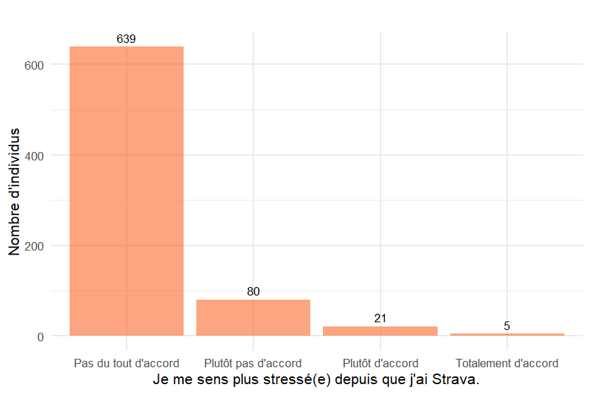

### Statistiques

#### Corrélations

##### PSS_Stress

| Variable | Corr_SCORE_PSS_Stress | P_value | Significatif |
| --- | --- | --- | --- |
| Score SIS | 0.18 | 0.0000 | <0.05 |
| Score OSF | 0.09 | 0.0198 | <0.05 |
| Score d’Exposition | 0.03 | 0.3905 | ≥0.05 |
| Appartenance à un club Strava | 0.02 | 0.6822 | ≥0.05 |
| Nombre de kudos reçus par activité | 0 | 0.9799 | ≥0.05 |
| Fréquence de publication | -0.07 | 0.0562 | ≥0.05 |
| Fréquence de consultation | 0.09 | 0.0192 | <0.05 |
| Nombre d’abonnés | 0.01 | 0.7643 | ≥0.05 |
| Nombre d’abonnements | 0.03 | 0.3757 | ≥0.05 |
| Ancienneté sur Strava (années) | -0.02 | 0.5038 | ≥0.05 |

##### PSS_Adaptation

| Variable | Corr_SCORE_PSS_Adaptation | P_value | Significatif |
| --- | --- | --- | --- |
| Score SIS | -0.36 | 0.0000 | <0.05 |
| Score OSF | -0.23 | 0.0000 | <0.05 |
| Score d’Exposition | -0.21 | 0.0000 | <0.05 |
| Appartenance à un club Strava | -0.15 | 0.0000 | <0.05 |
| Nombre de kudos reçus par activité | -0.1 | 0.0060 | <0.05 |
| Fréquence de publication | -0.12 | 0.0014 | <0.05 |
| Fréquence de consultation | -0.21 | 0.0000 | <0.05 |
| Nombre d’abonnés | -0.12 | 0.0008 | <0.05 |
| Nombre d’abonnements | -0.11 | 0.0036 | <0.05 |
| Ancienneté sur Strava (années) | 0 | 0.9613 | ≥0.05 |

#### Visualisation graphique

##### SIS- PSS Adaptation

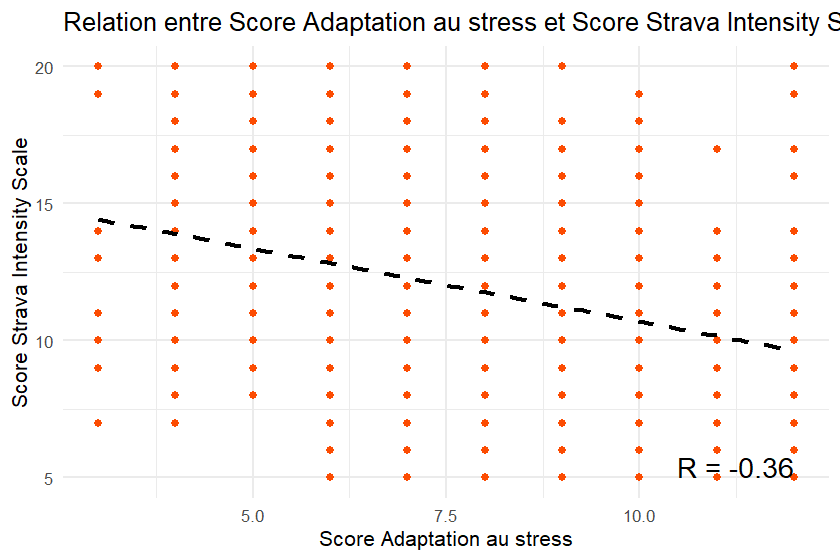

##### OSF - PSS Adaptation

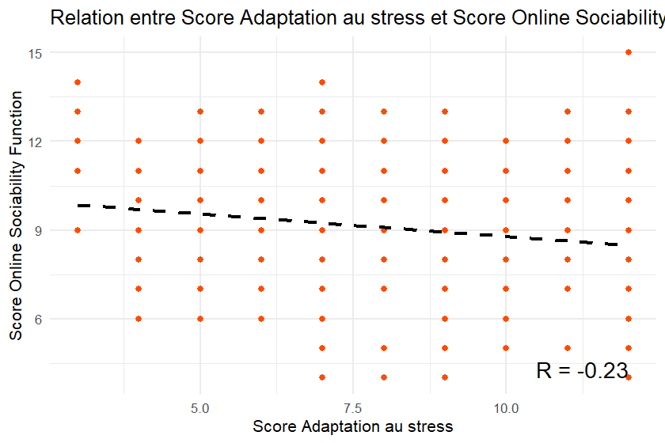

##### EXPO- PSS Adaptation

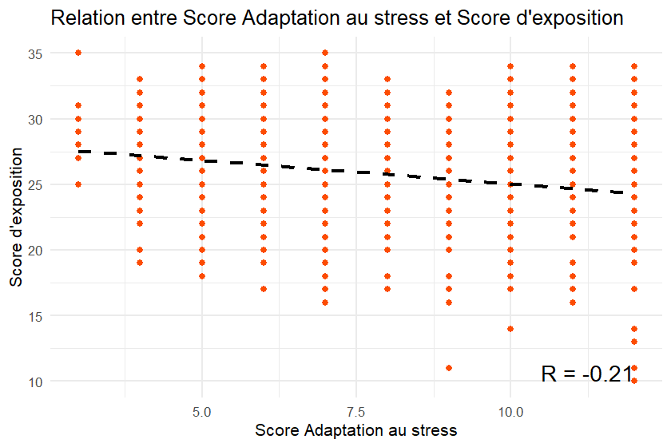

##### Fréquence consultation - PSS Adaptation

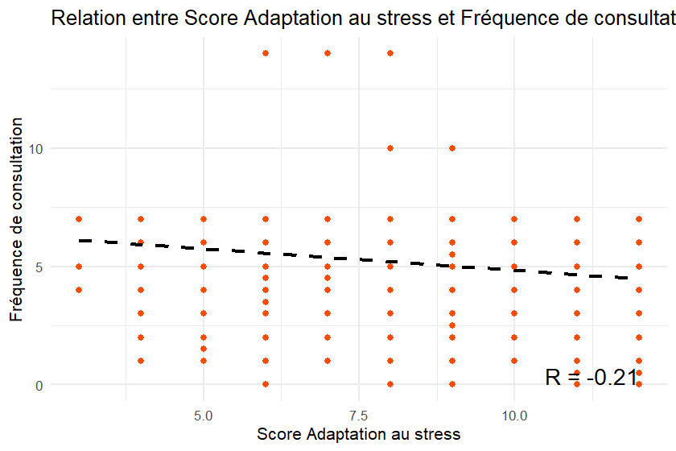

#### Test t de Student

| Variable | Student | p_value | Significatif | Gratuit | Payant |
| --- | --- | --- | --- | --- | --- |
| Catégorie d’abonnement et score PSS Stress | 1.487129 | 0.1374049 | ≥ 0.05 | 7.176348 | 6.96578 |

| Variable | Student | p_value | Significatif | Gratuit | Payant |
| --- | --- | --- | --- | --- | --- |
| Catégorie d’abonnement et score PSS Adaptation | 3.745083 | 0.0001943 | <0.05 | 8.526971 | 7.813688 |

#### Visualisation graphique

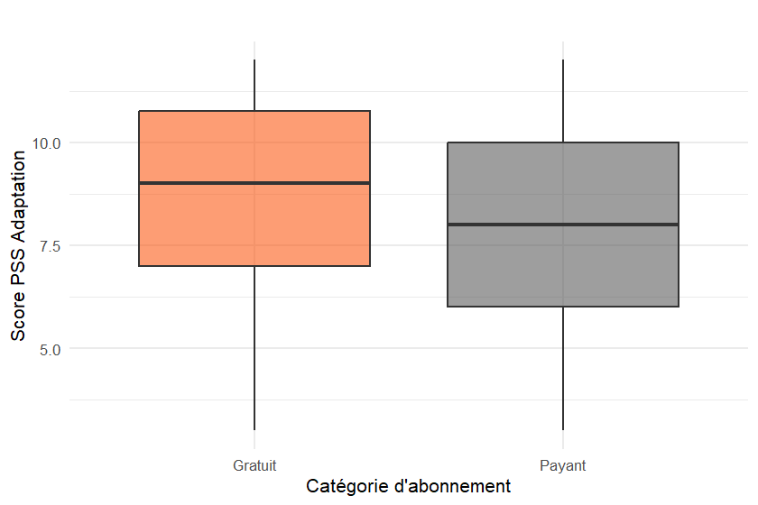

### Conclusion hypothèse 3

**Rappel de l’hypothèse 3 : plus les coureurs amateurs utilisent Strava, plus ils sont susceptibles de ressentir du stress.**

Il y a une faible corrélation positive entre le score PSS “stress perçu” et le score SIS (0.18). Les autres variables Strava n’ont pas de corrélation avec le score PSS “stress perçu”.

Il y a une corrélation moyenne négative entre le score PSS “adaptation au stress” et le score SIS (-0.36).

Il y a des faibles corrélations négatives entre le score PSS “adaptation au stress” et le score OSF (-0.23), le score d’exposition (-0.21), le nombre de clubs strava (-0.15), la fréquence de publication (-0.12), la fréquence de consultation (-0.21), le nombre d’abonnés (-0.12) et le nombre d’abonnements (-0.11).

Il n’y a pas de corrélation entre le score PSS “adaptation au stress” et le nombre de kudos reçus et l’ancienneté sur Strava.

Il n’est pas possible de mettre en évidence de différence pour le score PSS “stress perçu” pour les différentes catégories d’abonnement (payant/gratuit) (test t de Student, p>0.05). En revanche, il est possible de mettre en évidence des différences pour le score PSS “adaptation au stress” pour les différentes catégories d’abonnement : les personnes ayant un compte avec un abonnement gratuit ont un score PSS “adaptation au stress” plus élevé. (test de Student, p< 0.01, hautement significatif)

# Lien stress perçu - caractéristiques sportives (hypothèse 3)

Pour aller plus loin dans l’hypothèse 3, il s’agit de savoir s’il y a un lien entre les 2 scores PSS et les caractéristiques sportives.

On peut tester les 2 scores PSS avec les variables sportives suivantes :

- nombre de kilomètres par semaine (volume par semaine)
- nombre d’entraînements par semaine (fréquence entraînement)
- nombre de compétitions par an
- niveau
- type de coureur (trail/route, club/pas club, seul/en groupe)
- suivi d’un programme d’entraînement
- accompagnement par un coach
- type d’objectif 2025 s’il y en a un
- blessure ou non liée à la course à pied dans les 6 derniers mois
- durée de la pause d’une blessure liée à la course à pied

### Statistiques

#### Corrélations

##### PSS_Stress

| Variable | Corr_SCORE_PSS_Stress | P_value | Significatif |
| --- | --- | --- | --- |
| Nombre de kilomètres par semaine | -0.14 | 0.0001 | <0.05 |
| Nombre d’entraînements par semaine | -0.12 | 0.0007 | <0.05 |
| Compétitions | 0.03 | 0.4498 | ≥0.05 |

##### PSS_Adaptation

| Variable | Corr_SCORE_PSS_Adaptation | P_value | Significatif |
| --- | --- | --- | --- |
| Nombre de kilomètres par semaine | 0.04 | 0.2380 | ≥0.05 |
| Nombre d’entraînements par semaine | 0.02 | 0.5384 | ≥0.05 |
| Compétitions | -0.07 | 0.0622 | ≥0.05 |

#### Test t de Student

| Variable | Student | p_value | Significatif | Avec_coach | Sans_coach |
| --- | --- | --- | --- | --- | --- |
| Coach et PSS Stress | 0.4296672 | 0.6675623 | ≥ 0.05 | 7.16 | 7.087395 |

| Variable | Student | p_value | Significatif | Avec_coach | Sans_coach |
| --- | --- | --- | --- | --- | --- |
| Coach et PSS Adaptation | -1.39629 | 0.1630441 | ≥ 0.05 | 8.02 | 8.339496 |

| Variable | Student | p_value | Significatif | Avec_programme | Sans_programme |
| --- | --- | --- | --- | --- | --- |
| Programme et PSS Stress | 1.285613 | 0.1989788 | ≥ 0.05 | 7.23348 | 7.044402 |

| Variable | Student | p_value | Significatif | Avec_programme | Sans_programme |
| --- | --- | --- | --- | --- | --- |
| Programme et PSS Adaptation | -1.540705 | 0.1238143 | ≥ 0.05 | 8.061674 | 8.368726 |

| Variable | Student | p_value | Significatif | Blessure | Pas_de_blessure |
| --- | --- | --- | --- | --- | --- |
| Blessure et score PSS Stress | 2.683982 | 0.0074371 | <0.05 | 7.352941 | 6.971429 |

| Variable | Student | p_value | Significatif | Blessure | Pas_de_blessure |
| --- | --- | --- | --- | --- | --- |
| Blessure et score PSS Adaptation | -1.516272 | 0.1298759 | ≥ 0.05 | 8.082353 | 8.37551 |

#### Visualisation graphique

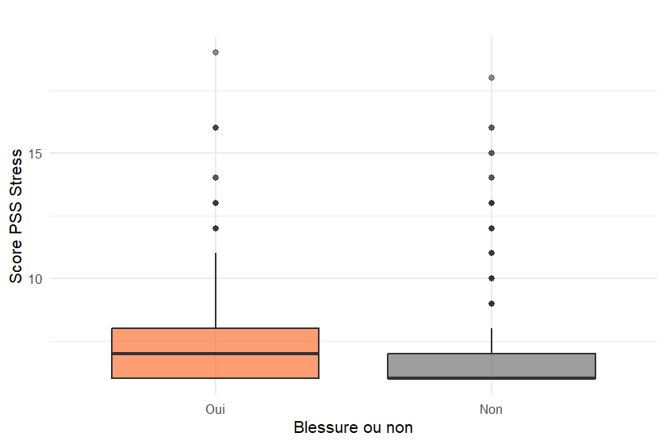

#### ANOVA

| Variable | F_value | P_value | Significatif | Débutant | Intermédiaire | Confirmé | Expert |
| --- | --- | --- | --- | --- | --- | --- | --- |
| Lien score PSS Stress et niveau | 2.179436 | 0.0891113 | ≥ 0.05 | 7.595238 | 7.172316 | 7.009615 | 6.648649 |
| Lien score PPS Adaptation et niveau | 1.214820 | 0.3033028 | ≥ 0.05 | 8.190476 | 8.435028 | 8.080128 | 8.486486 |

| Variable | F_value | P_value | Significatif |
| --- | --- | --- | --- |
| Lien score PSS Stress et type coureur | 1.0204891 | 0.4151548 | ≥ 0.05 |
| Lien score PSS Adaptation et type coureur | 0.4523426 | 0.8688120 | ≥ 0.05 |

| Type_coureur | Moyenne_Stress | Moyenne_Adaptation |
| --- | --- | --- |
| Route/Club/Seul | 7.318182 | 8.295454 |
| Route/Pas club/Seul | 7.281250 | 8.218750 |
| Route/Club/En groupe | 7.345029 | 8.052632 |
| Route/Pas club/En groupe | 7.333333 | 7.916667 |
| Trail/Club/Seul | 7.000000 | 8.382812 |
| Trail/Pas club/Seul | 7.101010 | 8.313131 |
| Trail/Club/En groupe | 6.946429 | 8.433036 |
| Trail/Pas club/En groupe | 6.771429 | 8.000000 |

| Variable | F_value | P_value | Significatif | Vingt_km | Cinquante_km | Cent_km | Cent_miles |
| --- | --- | --- | --- | --- | --- | --- | --- |
| Lien score PSS Stress et objectif 2025 | 2.680628 | 0.0306639 | < 0.05 | 7.215054 | 7.124294 | 7.300752 | 6.691729 |
| Lien score PSS Adaptation et objectif 2025 | 3.056992 | 0.0163092 | < 0.05 | 8.451613 | 8.220339 | 8.015038 | 8.887218 |

| Variable | F_value | P_value | Significatif | Jours | Semaines | Mois | Pas_de_pause |
| --- | --- | --- | --- | --- | --- | --- | --- |
| Lien score PSS Stress et pause blessure | 2.1257055 | 0.0759322 | ≥ 0.05 | 7.297619 | 7.505495 | 7.305085 | 7.047619 |
| Lien score PSS Adaptation et pause blessure | 0.8746612 | 0.4786220 | ≥ 0.05 | 7.952381 | 8.032967 | 8.389831 | 7.952381 |

#### Tests post hoc

| diff | lwr | upr | p adj | Comparison | Variable |
| --- | --- | --- | --- | --- | --- |
| -0.6090226 | -1.1434261 | -0.0746191 | 0.0162643 | 3-2 | Lien score PSS Stress et objectif 2025 |
| 0.8721805 | 0.1484043 | 1.5959566 | 0.0090918 | 3-2 | Lien score PSS Adaptation et objectif 2025 |

#### Visualisation graphique

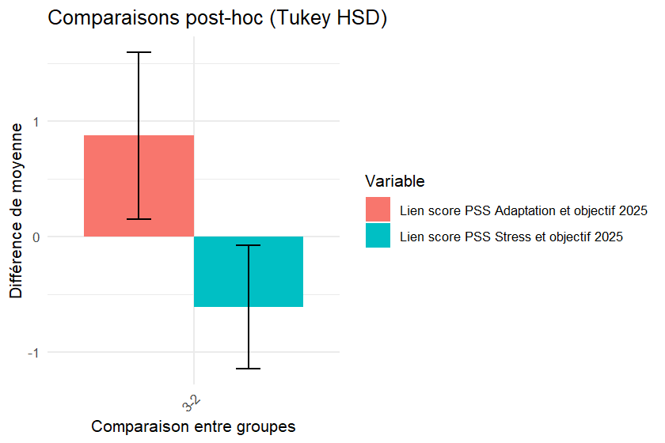

### Conclusion hypothèse 3

**Rappel de l’hypothèse 3 : plus les coureurs amateurs utilisent Strava, plus ils sont susceptibles de ressentir du stress.**

Il est possible de se demander si les 2 scores PSS ont un lien avec la pratique (est-ce que par exemple le fait d’avoir une score PSS “stress perçu” est en lien avec le nombre de kilomètres parcourus par semaine ?)

Il n’y a pas de corrélations entre le score PSS “adaptation au stress” et le nombre de kilomètres et d’entraînements par semaine et le nombre de compétitions par an.

Il y a une corrélation négative entre le score PSS “stress perçu” et le nombre de kilomètres par semaine (-0.14) et le nombre d’entraînement par semaine (-0.12). Ce sont des corrélations faibles (<0.3).

Il n’y a pas de corrélations entre le score PSS “stress perçu” et le nombre de compétitions par an.

Il n’est pas possible de mettre en évidence des différences de score PSS “stress perçu” ou PSS “adaptation au stress” avec le fait d’avoir un coach ou non ou le fait de suivre ou non un programme d’entraînement (test t de Student, p > 0.05). Il n’est pas possible de mettre en évidence des différences de score PSS “adaptation au stress” avec le fait d’avoir été blessé ou non ces 6 derniers mois (test t de Student, p>0.05).

Par contre, il est possible de mettre en évidence une différence de moyenne pour le score PSS “stress perçu” entre les personnes blessées ces 6 derniers mois ou non : les personnes blessées ces 6 derniers mois ont un score plus élevé.

Il n’est pas possible de mettre en évidence des différences significatives entre les 2 scores PSS et les différents niveaux de pratique, de même pour les types de coureurs, et les différentes durées de pause liées à des blesssures à cause de la course à pied pour les coureurs qui ont été blessés (ANOVA, p > 0.05).

Le stress perçu par l’utilisation de Strava semble être peu lié aux différentes caractéristiques de la pratique, sauf pour le fait d’être blessé et le fait d’avoir un objectif en 2025.

# Mesure de la motivation

Dans l’étude de Russell (2023) <sup>3</sup>, Strava est une source de motivation. Par exemple, il y a ce témoignagne concernant le fait de pouvoir interagir et se comparer “Pour ce marathon, je pense que nous essayons tous les cinq de suivre le même plan, donc je sais ce que chaque personne est censée faire chaque jour, donc j’ai l’impression que cela donne plus de responsabilité pour réaliser ce que je me suis fixé. Je ne sais pas si j’aurais suivi le programme d’entraînement autant que je l’ai fait si je n’avais pas eu Strava ou si je ne l’utilisais pas autant.” Il y a également ce témoignagne concernant le fait de voir ses progrès “Honnêtement, c’est une grande source de motivation de voir visuellement tous ces chiffres changer au fur et à mesure que je continue à courir.” et “c’est vraiment cool de voir jusqu’où j’ai progressé”.

Dans cette étude, une traduction et adaptation du BREQ-3 (Behavioural Regulation In Exercise Questionnaire) en 12 items est utilisée. Cette échelle mesure la motivation intrinsèque, intégrée et identifiée (motivations autodéterminées) et la motivation introjectée et externe (motivations non-autodéterminées) et l’amotivation <sup>12</sup>. Les alphas de Cronbach dans l’étude de Rocchi (2023)<sup>12</sup> ne sont pas mentionnés. L’Oméga de McDonald est utilisé à la place et les valeurs sont de :

- Motivation intrinsèque 0.72 - 0.82
- Régulation intégrée 0.56 - 0.79
- Régulation identifiée 0.44 - 0.76
- Régulation introjectée 0.60 - 0.77
- Régulation externe 0.54 - 0.70
- Amotivation 0.59 - 0.63

Le score RAI dans l’échantillon est assez haut, ce qui suggère que les coureurs ont un haut niveau de motivation autonome (motivation intrinsèque, intégrée et identifiée).

### Motivation intrinsèque

```
## L'alpha de Cronbach sur les 2 items est de 0.545949601260713
```

#### BREQ 1

| Moyenne | Médiane | Ecart_type |
| --- | --- | --- |
| 3.816107 | 4 | 0.4365781 |

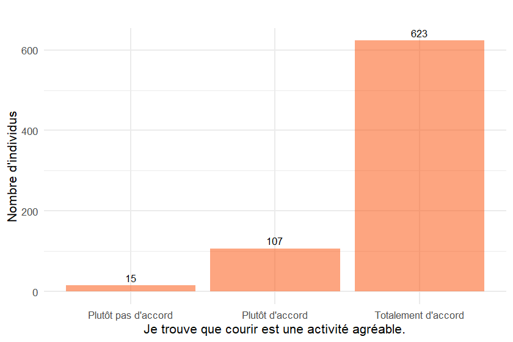

#### BREQ 2

| Moyenne | Médiane | Ecart_type |
| --- | --- | --- |
| 3.233557 | 3 | 0.8306633 |

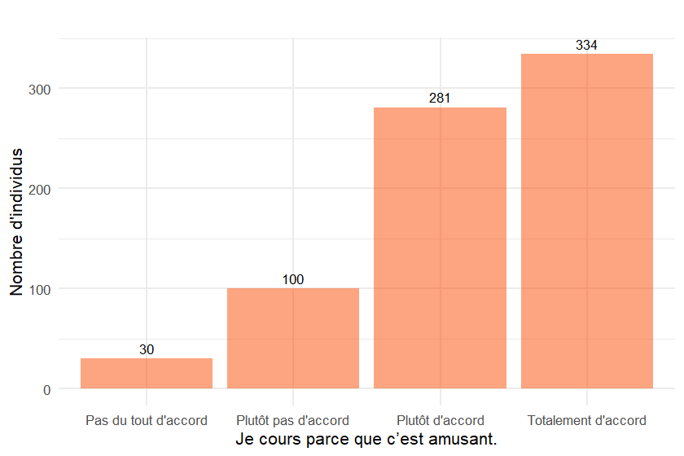

#### Score motivation intrinsèque

| Item | Moyenne | Médiane | Ecart_type |
| --- | --- | --- | --- |
| BREQ 1 | 3.816107 | 4.0 | 0.4365781 |
| BREQ 2 | 3.233557 | 3.0 | 0.8306633 |
| SCORE_BREQ_Intrinseque | 3.524832 | 3.5 | 0.5502817 |

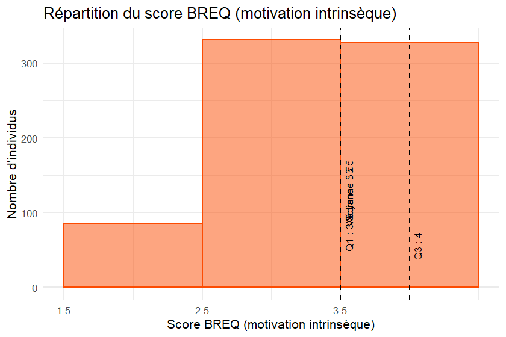